# BARBER_exam_3

Samantha Barber

2022-11-29

## Loading and cleaning data for FacultySalaries_1995

I will breifly descibe my cleaning and loading of data here so we can move on to the figures and models tested on our data sets.

My file path was “./data/FacultySalaries_1995.csv”. I started out with messy data so I needed to clean and organize it.

Cleaning the data took me a minute. I had to organize and separate ranks into full, assoc, and assist data sets.

# Fig 1 for Faculty Salaraies Data.

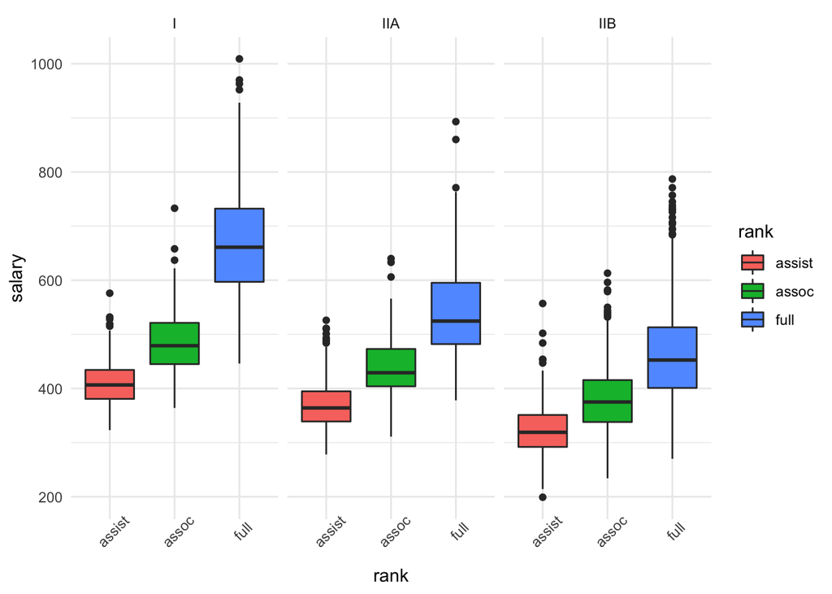

```r
finaldat %>%
  filter(!tier=="VIIB") %>%
  ggplot(aes(rank,salary,fill=rank))+
  geom_boxplot()+
  facet_wrap(~tier)+
  theme_minimal()+
  theme(axis.text.x = element_text (angle = 45))
```

# Anova model

At first you will see how I created my anova model, and then I created a table to show a tidy anova model. in the table I created below it rounded the P.Value to 0 to show its significance.

```r
anova<-aov(salary~state+ tier+ rank, data = finaldat)
summary(anova)
```

```
##               Df   Sum Sq Mean Sq F value Pr(>F)
## state         51  5682396  111420   30.66 <2e-16 ***
## tier           2  7072361 3536180  972.96 <2e-16 ***
## rank           2 16529771 8264885 2274.04 <2e-16 ***
## Residuals   3299 11990072    3634
## ---
## Signif. codes:  0 '***' 0.001 '**' 0.01 '*' 0.05 '.' 0.1 ' ' 1
## 128 observations deleted due to missingness
```

```r
broom::tidy(anova) %>%
  kable()
```

| term | df | sumsq | meansq | statistic | p.value |
| --- | --- | --- | --- | --- | --- |
| state | 51 | 5682396 | 111419.523 | 30.65645 | 0 |
| tier | 2 | 7072361 | 3536180.347 | 972.95986 | 0 |
| rank | 2 | 16529771 | 8264885.322 | 2274.03608 | 0 |
| Residuals | 3299 | 11990072 | 3634.457 | NA | NA |

# Loading and cleaning for Juniper_Oils.

I loaded the data set, and cleaned it so we had good data to work with and create graphs and models with.

# Graph 2 for Juniper Oils.

This graph represents the years since burn and concentration of the chemical.

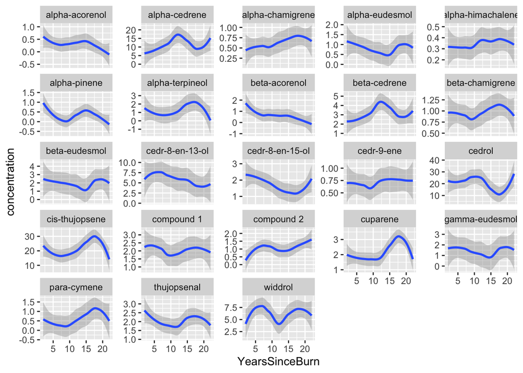

```r
cleandat2 %>%
  group_by(chemicals) %>%
  ggplot(aes(YearsSinceBurn,concentration))+
  geom_smooth()+
  facet_wrap(~chemicals,scales="free_y")
```

# Creating Jumper Oils model.

I created a table with my model that filtered out the significant values I wanted with a P value below 0.05.

```r
tidy(model2) %>%
  filter(p.value<0.05)
```

```
## # A tibble: 6 × 5
##   term                                   estimate std.error statistic  p.value
##   <chr>                                     <dbl>     <dbl>     <dbl>    <dbl>
## 1 chemicalsalpha-cedrene                    7.88      1.93       4.08 4.97e- 5
## 2 chemicalscedr-8-en-13-ol                  7.62      1.93       3.95 8.72e- 5
## 3 chemicalscedrol                          22.5       1.93      11.7  5.12e-29
## 4 chemicalscis-thujopsene                  17.3       1.93       8.95 2.93e-18
## 5 chemicalswiddrol                          5.82      1.93       3.01 2.69e- 3
## 6 chemicalscis-thujopsene:YearsSinceBurn    0.332     0.141      2.35 1.90e- 2
```